# Gapminder2

```r
library(tidyverse)
library(gapminder)
```

# Compute a trimmed mean of life expectancy for different years. Or a weighted mean, weighting by population. Just try something other than the plain vanilla mean.

```r
gapminder %>%
  group_by(year) %>%
 transmute(wm= weighted.mean(lifeExp,pop)) %>%  #Coumputed the weighted mean of lifeExp.
 knitr::kable()
```

| year | wm |
| --- | --- |
| 1952 | 48.94424 |
| 1957 | 52.12189 |
| 1962 | 52.32438 |
| 1967 | 56.98431 |
| 1972 | 59.51478 |
| 1977 | 61.23726 |
| 1982 | 62.88176 |
| 1987 | 64.41635 |
| 1992 | 65.64590 |
| 1997 | 66.84934 |
| 2002 | 67.83904 |
| 2007 | 68.91909 |
| 1952 | 48.94424 |
| 1957 | 52.12189 |
| 1962 | 52.32438 |
| 1967 | 56.98431 |
| 1972 | 59.51478 |
| 1977 | 61.23726 |
| 1982 | 62.88176 |
| 1987 | 64.41635 |
| 1992 | 65.64590 |
| 1997 | 66.84934 |
| 2002 | 67.83904 |
| 2007 | 68.91909 |
| 1952 | 48.94424 |
| 1957 | 52.12189 |
| 1962 | 52.32438 |
| 1967 | 56.98431 |
| 1972 | 59.51478 |
| 1977 | 61.23726 |

[output cut: 1674 more lines]

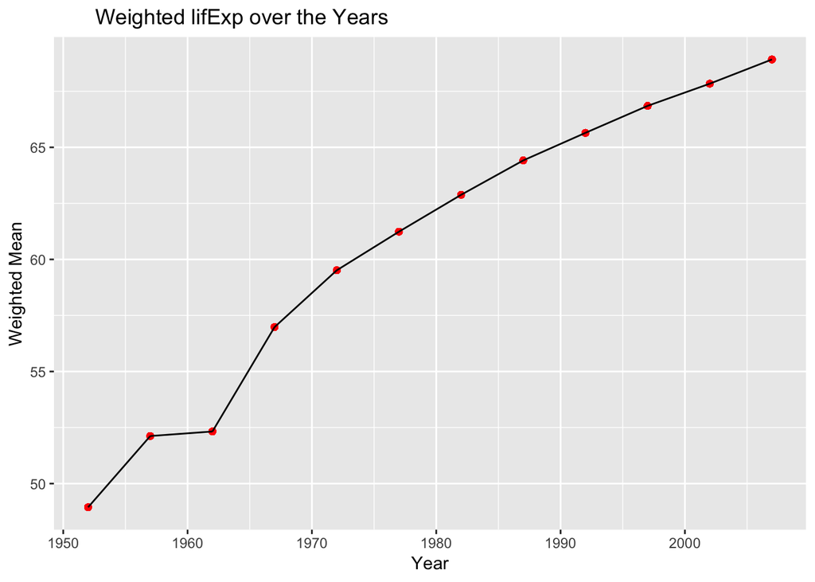

```r
gapminder %>%
  group_by(year) %>%
 transmute(wm= weighted.mean(lifeExp,pop)) %>%
ggplot(aes(year,wm))+
  geom_point(color="red")+
  geom_line()+ # creates linegraph of weighted lifeExp
  ggtitle("       Weighted lifExp over the Years")+   #added title
  xlab("Year")+ #x-axis lable
  ylab("Weighted Mean") #y-axis lable
```

#Comments:

#Graph depicts the weighted mean of lifeExp over the years.

#Easliy computed the weighted mean using weighted.mean() function which i learnt during the development of this code.

# How is life expectancy changing over time on different continents?

```r
gapminder %>%
  group_by(continent,lifeExp,year) %>%  #grouping by continent, lifeExp and year
  knitr::kable()
```

| country | continent | year | lifeExp | pop | gdpPercap |
| --- | --- | --- | --- | --- | --- |
| Afghanistan | Asia | 1952 | 28.80100 | 8425333 | 779.4453 |
| Afghanistan | Asia | 1957 | 30.33200 | 9240934 | 820.8530 |
| Afghanistan | Asia | 1962 | 31.99700 | 10267083 | 853.1007 |
| Afghanistan | Asia | 1967 | 34.02000 | 11537966 | 836.1971 |
| Afghanistan | Asia | 1972 | 36.08800 | 13079460 | 739.9811 |
| Afghanistan | Asia | 1977 | 38.43800 | 14880372 | 786.1134 |
| Afghanistan | Asia | 1982 | 39.85400 | 12881816 | 978.0114 |
| Afghanistan | Asia | 1987 | 40.82200 | 13867957 | 852.3959 |
| Afghanistan | Asia | 1992 | 41.67400 | 16317921 | 649.3414 |
| Afghanistan | Asia | 1997 | 41.76300 | 22227415 | 635.3414 |
| Afghanistan | Asia | 2002 | 42.12900 | 25268405 | 726.7341 |
| Afghanistan | Asia | 2007 | 43.82800 | 31889923 | 974.5803 |
| Albania | Europe | 1952 | 55.23000 | 1282697 | 1601.0561 |
| Albania | Europe | 1957 | 59.28000 | 1476505 | 1942.2842 |
| Albania | Europe | 1962 | 64.82000 | 1728137 | 2312.8890 |
| Albania | Europe | 1967 | 66.22000 | 1984060 | 2760.1969 |
| Albania | Europe | 1972 | 67.69000 | 2263554 | 3313.4222 |
| Albania | Europe | 1977 | 68.93000 | 2509048 | 3533.0039 |
| Albania | Europe | 1982 | 70.42000 | 2780097 | 3630.8807 |
| Albania | Europe | 1987 | 72.00000 | 3075321 | 3738.9327 |
| Albania | Europe | 1992 | 71.58100 | 3326498 | 2497.4379 |
| Albania | Europe | 1997 | 72.95000 | 3428038 | 3193.0546 |
| Albania | Europe | 2002 | 75.65100 | 3508512 | 4604.2117 |
| Albania | Europe | 2007 | 76.42300 | 3600523 | 5937.0295 |
| Algeria | Africa | 1952 | 43.07700 | 9279525 | 2449.0082 |
| Algeria | Africa | 1957 | 45.68500 | 10270856 | 3013.9760 |
| Algeria | Africa | 1962 | 48.30300 | 11000948 | 2550.8169 |
| Algeria | Africa | 1967 | 51.40700 | 12760499 | 3246.9918 |
| Algeria | Africa | 1972 | 54.51800 | 14760787 | 4182.6638 |
| Algeria | Africa | 1977 | 58.01400 | 17152804 | 4910.4168 |

[output cut: 1674 more lines]

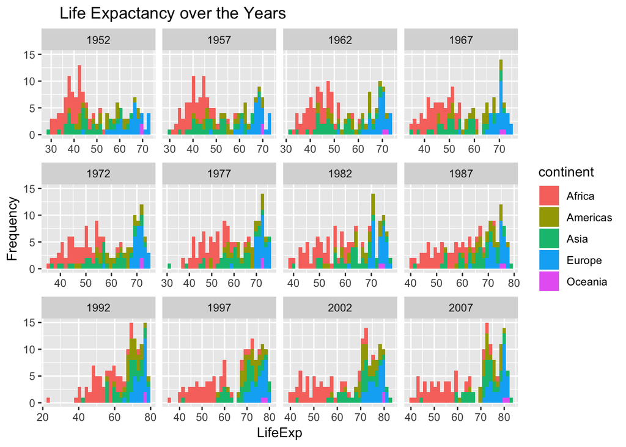

```r
gapminder %>%
  ggplot(aes(lifeExp))+ #to develop a ggplot with lifeExp on x-axis.
  geom_histogram(aes(fill=continent),bins=30)+ #developed a binned histogram  with each continent having its                                                        separate colour.
  ggtitle("    Life Expactancy over the Years")+ #added title
  xlab("LifeExp")+ #x-axis label
  ylab("Frequency")+ #y-axis label
  facet_wrap(~year,scales="free_x") #created individual plots for each year in the Gapminder dataset with                                         their individual scales.
```

#From the graphs we infer that over the years for continents like Africa and Asia the lifeExp has increased,ie. in the earlier times the frequency of lifeExp years like 30 and 40 was high which has decreased over time and lifeExp like 70 and 80 have high frequnecy now. While continents like Europe and Oceania have maintained a high life throughout.

#Easy to develop the code but made me think whether to wrap by year or continent.Referred to cm007.

# Report the absolute and/or relative abundance of countries with low life expectancy over time by continent: Compute some measure of worldwide life expectancy – you decide – a mean or median or some other quantile or perhaps your current age. Then determine how many countries on each continent have a life expectancy less than this benchmark, for each year.

```r
gapminder %>%
summarise(mu=mean(lifeExp)) #to calculate the mean life expectancy
```

```
## # A tibble: 1 x 1
##      mu
##   <dbl>
## 1  59.5
```

```r
gapminder %>%

  filter(lifeExp<mean(lifeExp)) %>%
  #filtered all rows that have lifeExp less than the mean lifeExp.

  count(continent,year)
```

```
## # A tibble: 40 x 3
##    continent  year     n
##    <fct>     <int> <int>
##  1 Africa     1952    52
##  2 Africa     1957    52
##  3 Africa     1962    51
##  4 Africa     1967    50
##  5 Africa     1972    50
##  6 Africa     1977    49
##  7 Africa     1982    43
##  8 Africa     1987    39
##  9 Africa     1992    38
## 10 Africa     1997    39
## # ... with 30 more rows
```

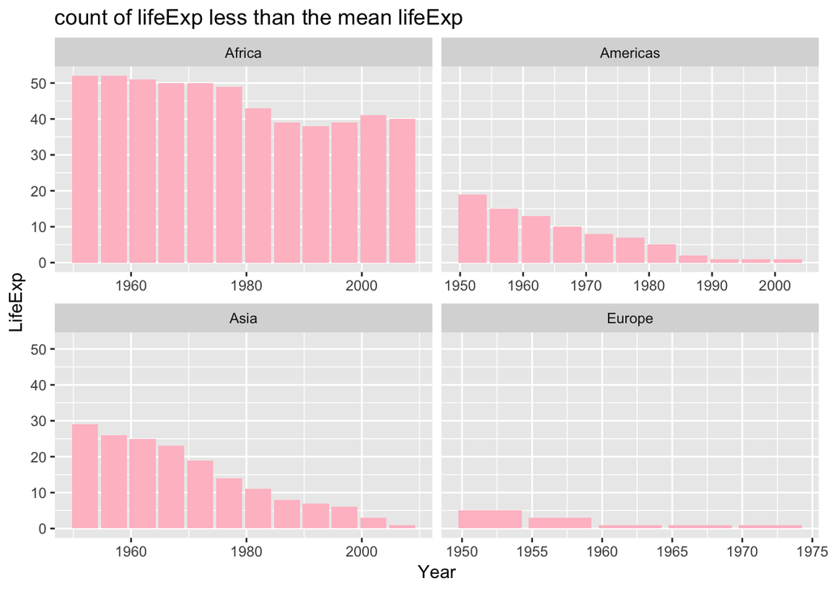

```r
#Counts the number of countries yearwise in the continents that have lifExp less than the mean lifeExp.


gapminder %>%
filter(lifeExp<mean(lifeExp)) %>%
ggplot(aes(year))+
facet_wrap(~continent,scales="free_x")+
  #returns the plot for each continent separately with their own individual scales

  geom_bar(fill="pink")+
  #creats the bar plot counting the countiries within each continent,for each year having lifeExp less than the mean lifeExp.
  ggtitle("count of lifeExp less than the mean lifeExp")+ # added title
  xlab("Year")+ #x-axis lable
  ylab("LifeExp") #y-axis lable
```

#Comments:

#It was interesting to develop this code that made me think how I should count the countries in each continent that have lifeExp less than the mean LifeExp and creat an appropriate graph for it using facet_wrap.

# To Get the maximum and minimum of GDP per capita for all continents.

```r
 gapminder %>%
  group_by(continent) %>%
 summarise(max=max(gdpPercap),min=min(gdpPercap)) #to find max and min gdp per capita.
```

```
## # A tibble: 5 x 3
##   continent     max    min
##   <fct>       <dbl>  <dbl>
## 1 Africa     21951.   241.
## 2 Americas   42952.  1202.
## 3 Asia      113523.   331
## 4 Europe     49357.   974.
## 5 Oceania    34435. 10040.
```

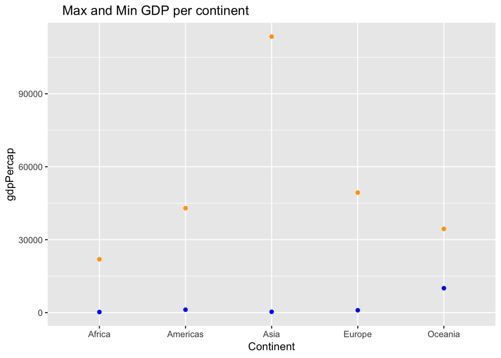

```r
gapminder %>%
  group_by(continent) %>%
 summarise(max=max(gdpPercap),min=min(gdpPercap)) %>%
  ggplot()+
  geom_point(aes(continent,max),color="orange")+ #creates scatterplot of min and max                                                     gdpPercap
  geom_point(aes(continent,min),color="blue")+
  ggtitle("    Max and Min GDP per continent")+   #added title
  xlab("Continent")+ #x-axis lable
  ylab("gdpPercap") #y-axis lable
```

#Comments:

#Easy to find the max and min GDP per capita for all continents.

#Ploted the joint scatter plot of the max and min GDP per capita of each continent.